# 美国金县房价影响因素探究

林恒基 2018201708，李政萱 2018201700，董钦源 2018201653，孙雨忱 2018201169，张雯丽 2018200701，曹竞轩 2018202075

# 数据准备

## 数据来源

### 来源与背景

本工作中使用的数据来自于Kaggle上的数据集[House Sales in King County, USA](https://www.kaggle.com/harlfoxem/housesalesprediction)，其中包括了金县从2014年5月到2015年5月的房屋销售数据。

金县是美国华盛顿州的一个县，县都西雅图。县人口约220万人，是华盛顿州最大的县，也是美国第13大县。

### 原始变量说明

1. 交易编号：该次房屋交易行为的独特编号。
2. 销售时间：房产被售出的具体时间（精确到日）。
3. 销售价格：房产的销售价格，单位美元。
4. 卧室数：房产的卧室数量。
5. 浴室数：房产的浴室数量（0.5代表卧室旁附带的浴室，只有厕所没有淋浴设施）。
6. 居住面积：房产的居住面积（地上加地下），单位平方英尺。
7. 土地面积：房产附带的土地面积，如花园、车库、耕地等，单位平方英尺。
8. 楼层数：房产的楼层数（0.5代表阁楼）。
9. 是否海景房：房产是否是海景房。
10. 视野：房产的视野等级，即房周围的景色是否好看。取值0～4，数值越高代表视野越好。
11. 成色：房产的成色，即“几成新”。取值1～5，数值越高代表越新，越低代表越破旧。
12. 建筑设计水平：房产的建筑设计水平，由专家审定，评判标准包括如房间结构的划分、窗户的朝向等是否合理。取值1～13，数值越高代表设计水平越高。
13. 地上建筑面积：房产地上部分的面积，单位平方英尺。
14. 地下建筑面积：房产地下部分的面积，即地下室面积，没有地下室则取0，单位平方英尺。
15. 建筑年份：房产的建筑年份。
16. 翻新年份：房产的翻修年份，若未翻修过则为0。
17. 邮编：房产所处地区的邮编。
18. 纬度：房产所处的纬度。
19. 经度：房产所处的经度。
20. 附近15间房屋平均居住面积：房产附近15间房屋的平均居住面积。
21. 附近15间房屋平均土地面积：房产附近15间房屋的平均土地面积。

## 数据清洗

1. 检测并去除含空值的个别样本。
2. 去除一个卧室数为33的异常样本。
3. 去除少量土地面积大于10000平方英尺的异常样本。
4. 去除少量地上建筑面积加上地下建筑面积不等于居住面积的异常样本。

## 变量初步筛选

1. 去除交易编号、邮编，由于其作为数值型变量无解释意义。
2. 去除翻新年份。由于未翻新的房产该变量取0，翻新过的房产该变量取翻新年份，故该变量同样作为数值型变量无解释意义。
3. 去除附近15间房屋平均居住面积和附近15间房屋平均土地面积，由于其分别和居住面积和土地面积高度相关。
4. 去除地上建筑面积和地下建筑面积。一是因为它们的和就等于居住面积，存在完全共线性；二是因为地下建筑面积存在大量为0的值（即没有地下室）。与翻新年份同理，不具有解释意义。

## 特征提取

#### 每间卧室平均浴室数

在描述性统计中发现，卧室数和浴室数均与居住面积高度相关，故去除这两个变量并加入该衍生变量，其值等于卧室数除以浴室数。经检验该变量与居住面积相关性较低。

#### 有无地下室

从地下建筑面积一列中提取该衍生变量，地下建筑面积为0说明无地下室，否则说明有地下室。

#### 销售年份、销售季度

这两个衍生变量由原变量“销售时间”中提取而来。同时删去原变量。

#### 是否位于西雅图

原数据中“邮编”一栏内的邮编主要由981或980开头，少量是由其他字串开头。经查阅美国邮编规律相关资料得知，981开头的邮编主要对应西雅图辖内地区，其他则对应金县的其他地区（仅有少量例外）。故据此提取该衍生变量。

#### 最近一次翻新距今年份

该衍生变量等于购买年份减去最近一次修建或翻新的年份。例如，购买年份2015，建筑年份1995，翻新年份0（未翻新），则该衍生变量的值为2015 - 1995 = 20。

#### 距最近优质啤酒厂的距离

通过经纬度，结合当地的地图信息计算而得。选取了当地的6个名气大的啤酒厂，计算每间房产离这6个啤酒厂的最近距离，单位英里。这个变量的解释意义为，当地啤酒厂附近通常会有很多餐厅和酒吧等，属于比较繁华的地区。

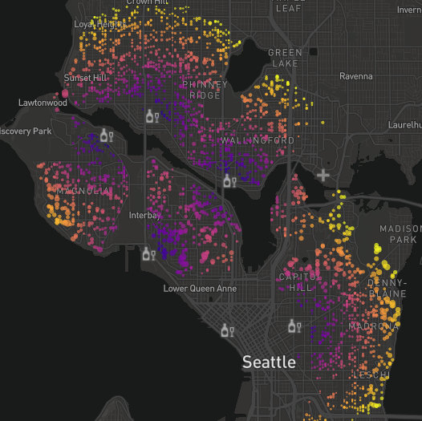

距最近优质啤酒厂的距离

#### 距医院的交通距离

通过经纬度，结合当地的地图信息计算而得。结合当地的道路信息，计算每间房产离华盛顿大学医学中心（University of Washington Medical Center）的交通距离，单位小时。

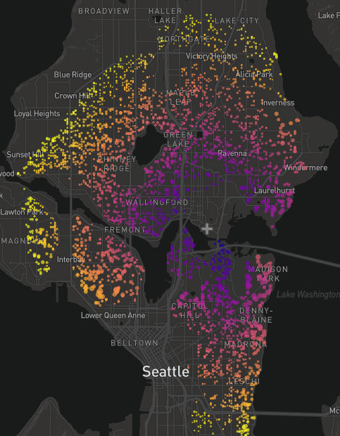

距医院的交通距离

#### 是否邻近海岸

通过经纬度，结合当地的地图信息计算而得。计算每间房产离最近的海岸线的垂直距离，并将距离小于0.25英里的房产标记为“邻近海岸”，其他标记为“不邻近海岸”。由于原变量“是否海景房”只判断房产的网页上是否加了“海景”标签，因此漏掉了一些在海边但未打上标签的房子，导致大部分取值为0。这里删去它，用新的衍生变量替代之。

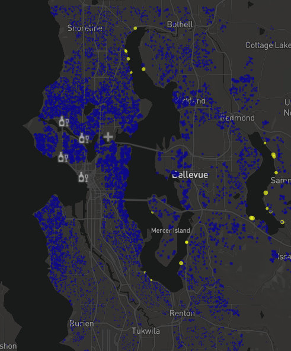

是否海景房

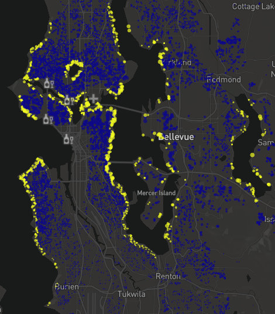

是否邻近海岸

## 最终数据集展示

|  | 销售价格 | 居住面积 | 土地面积 | 楼层数 | 视野 | 成色 | 建筑设计水平 | 建筑年份 | 纬度 | 经度 | 每间卧室平均浴室数 | 有无地下室 | 距最近优质啤酒厂的距离 | 距医院的交通距离 | 销售年份 | 销售季度 | 是否位于西雅图 | 最近一次翻新距今年份 | 是否邻近海岸 |
| --- | --- | --- | --- | --- | --- | --- | --- | --- | --- | --- | --- | --- | --- | --- | --- | --- | --- | --- | --- |
| 9628 | 427500 | 1480 | 4200 | 1.5 | 0 | 3 | 7 | 1925 | 47.6147 | -122.298 | 3.000000 | 无 | 1.05 | 0.0883578 | 2014 | Q4 | 是 | 89 | 否 |
| 9452 | 235500 | 1380 | 7600 | 1.0 | 0 | 4 | 7 | 1971 | 47.3489 | -122.306 | 2.000000 | 有 | 18.24 | 0.5015798 | 2014 | Q3 | 否 | 43 | 否 |
| 7767 | 275000 | 1170 | 1174 | 2.0 | 0 | 3 | 7 | 2007 | 47.5459 | -122.376 | 2.000000 | 有 | 4.76 | 0.3138725 | 2014 | Q4 | 是 | 7 | 否 |
| 14870 | 339950 | 820 | 681 | 3.0 | 0 | 3 | 8 | 2006 | 47.6619 | -122.352 | 2.000000 | 无 | 0.95 | 0.0828666 | 2014 | Q2 | 是 | 8 | 否 |
| 8920 | 516000 | 1640 | 3090 | 1.0 | 0 | 4 | 7 | 1925 | 47.6790 | -122.319 | 1.142857 | 有 | 2.38 | 0.0734147 | 2014 | Q3 | 是 | 89 | 否 |
| 4417 | 442500 | 1970 | 7902 | 1.0 | 0 | 3 | 8 | 1960 | 47.7249 | -122.298 | 1.777778 | 有 | 5.40 | 0.1776097 | 2015 | Q1 | 是 | 55 | 否 |

# 模型建立

## 模型一：全变量回归

```
##
## Call:
## lm(formula = log(销售价格) ~ 居住面积 + 土地面积 +
##     楼层数 + 视野 + 成色 + 建筑设计水平 + 建筑年份 +
##     纬度 + 经度 + 每间卧室平均浴室数 + 有无地下室 +
##     距最近优质啤酒厂的距离 + 距医院的交通距离 +
##     销售年份 + 销售季度 + 是否位于西雅图 + 最近一次翻新距今年份 +
##     是否邻近海岸, data = data1)
##
## Residuals:
##      Min       1Q   Median       3Q      Max
## -1.16049 -0.11769  0.00693  0.13495  0.95208
##
## Coefficients:
##                          Estimate Std. Error t value Pr(>|t|)
## (Intercept)             7.472e+01  9.967e+00   7.497 9.78e-14 ***
## 居住面积                2.510e-04  1.052e-05  23.856  < 2e-16 ***
## 土地面积                8.575e-07  2.954e-06   0.290 0.771614
## 楼层数                  1.489e-02  1.391e-02   1.070 0.284582
## 视野                    6.765e-02  8.952e-03   7.557 6.25e-14 ***
## 成色                    3.252e-02  8.483e-03   3.833 0.000131 ***
## 建筑设计水平            1.396e-01  7.890e-03  17.698  < 2e-16 ***
## 建筑年份               -2.958e-03  4.234e-04  -6.986 3.84e-12 ***
## 纬度                   -7.170e-02  7.397e-02  -0.969 0.332522
## 经度                    4.386e-01  6.987e-02   6.277 4.23e-10 ***
## 每间卧室平均浴室数     -3.033e-02  8.787e-03  -3.452 0.000569 ***
## 有无地下室有           -6.613e-03  1.230e-02  -0.538 0.590858
## 距最近优质啤酒厂的距离 -2.243e-02  1.872e-03 -11.985  < 2e-16 ***
## 距医院的交通距离       -1.059e+00  7.075e-02 -14.973  < 2e-16 ***
## 销售年份2015            7.859e-02  1.692e-02   4.645 3.63e-06 ***
## 销售季度Q2              7.982e-02  1.647e-02   4.845 1.36e-06 ***
## 销售季度Q3              8.320e-02  2.211e-02   3.763 0.000173 ***
## 销售季度Q4              7.479e-02  2.254e-02   3.317 0.000925 ***
## 是否位于西雅图是       -9.960e-02  1.795e-02  -5.548 3.28e-08 ***
## 最近一次翻新距今年份   -1.042e-03  4.233e-04  -2.461 0.013955 *
## 是否邻近海岸是          1.389e-01  2.072e-02   6.704 2.64e-11 ***
## ---
## Signif. codes:  0 '***' 0.001 '**' 0.01 '*' 0.05 '.' 0.1 ' ' 1
##
## Residual standard error: 0.2125 on 1979 degrees of freedom
## Multiple R-squared:  0.7867, Adjusted R-squared:  0.7846
## F-statistic:   365 on 20 and 1979 DF,  p-value: < 2.2e-16
```

## 自变量筛选（逐步回归）

```
## Start:  AIC=-6174.27
## log(销售价格) ~ 居住面积 + 土地面积 + 楼层数 +
##     视野 + 成色 + 建筑设计水平 + 建筑年份 + 纬度 +
##     经度 + 每间卧室平均浴室数 + 有无地下室 +
##     距最近优质啤酒厂的距离 + 距医院的交通距离 +
##     销售年份 + 销售季度 + 是否位于西雅图 + 最近一次翻新距今年份 +
##     是否邻近海岸
##
##                          Df Sum of Sq     RSS     AIC
## - 土地面积                1    0.0038  89.372 -6176.2
## - 有无地下室              1    0.0131  89.382 -6176.0
## - 纬度                    1    0.0424  89.411 -6175.3
## - 楼层数                  1    0.0517  89.420 -6175.1
## <none>                                 89.369 -6174.3
## - 最近一次翻新距今年份    1    0.2734  89.642 -6170.2
## - 每间卧室平均浴室数      1    0.5380  89.907 -6164.3
## - 成色                    1    0.6635  90.032 -6161.5
## - 销售季度                3    1.0763  90.445 -6156.3
## - 销售年份                1    0.9742  90.343 -6154.6
## - 是否位于西雅图          1    1.3899  90.759 -6145.4
## - 经度                    1    1.7793  91.148 -6136.8
## - 是否邻近海岸            1    2.0296  91.398 -6131.4
## - 建筑年份                1    2.2041  91.573 -6127.5
## - 视野                    1    2.5792  91.948 -6119.4
## - 距最近优质啤酒厂的距离  1    6.4862  95.855 -6036.1
## - 距医院的交通距离        1   10.1245  99.493 -5961.6
## - 建筑设计水平            1   14.1438 103.512 -5882.4
## - 居住面积                1   25.6993 115.068 -5670.8
##
## Step:  AIC=-6176.18
## log(销售价格) ~ 居住面积 + 楼层数 + 视野 + 成色 +
##     建筑设计水平 + 建筑年份 + 纬度 + 经度 + 每间卧室平均浴室数 +
##     有无地下室 + 距最近优质啤酒厂的距离 + 距医院的交通距离 +
##     销售年份 + 销售季度 + 是否位于西雅图 + 最近一次翻新距今年份 +
##     是否邻近海岸
##
##                          Df Sum of Sq     RSS     AIC
## - 有无地下室              1    0.0171  89.390 -6177.8
## - 纬度                    1    0.0388  89.411 -6177.3
## - 楼层数                  1    0.0503  89.423 -6177.1
```

[output cut: 51 more lines]

```
## - 楼层数                  1     0.113  89.536 -6178.5
## - 最近一次翻新距今年份    1     0.272  89.695 -6175.0
## - 每间卧室平均浴室数      1     0.543  89.966 -6168.9
## - 成色                    1     0.668  90.091 -6166.2
## - 销售季度                3     1.078  90.502 -6161.1
## - 销售年份                1     0.970  90.393 -6159.5
## - 是否位于西雅图          1     1.482  90.905 -6148.2
## - 经度                    1     1.804  91.227 -6141.1
## - 是否邻近海岸            1     2.057  91.480 -6135.6
## - 建筑年份                1     2.339  91.762 -6129.4
## - 视野                    1     2.567  91.991 -6124.4
## - 距最近优质啤酒厂的距离  1     7.470  96.893 -6020.6
## - 距医院的交通距离        1    13.494 102.917 -5900.0
## - 建筑设计水平            1    14.326 103.749 -5883.8
## - 居住面积                1    32.760 122.183 -5556.8
```

## 模型二：部分变量回归

```
##
## Call:
## lm(formula = log(销售价格) ~ 居住面积 + 楼层数 + 视野 +
##     成色 + 建筑设计水平 + 建筑年份 + 经度 + 每间卧室平均浴室数 +
##     距最近优质啤酒厂的距离 + 距医院的交通距离 +
##     销售年份 + 销售季度 + 是否位于西雅图 + 最近一次翻新距今年份 +
##     是否邻近海岸, data = data1)
##
## Residuals:
##      Min       1Q   Median       3Q      Max
## -1.15833 -0.11830  0.00721  0.13472  0.95426
##
## Coefficients:
##                          Estimate Std. Error t value Pr(>|t|)
## (Intercept)             6.985e+01  8.288e+00   8.429  < 2e-16 ***
## 居住面积                2.496e-04  9.262e-06  26.946  < 2e-16 ***
## 楼层数                  1.771e-02  1.118e-02   1.584 0.113345
## 视野                    6.746e-02  8.943e-03   7.543 6.94e-14 ***
## 成色                    3.256e-02  8.461e-03   3.848 0.000123 ***
## 建筑设计水平            1.402e-01  7.865e-03  17.819  < 2e-16 ***
## 建筑年份               -3.020e-03  4.194e-04  -7.201 8.48e-13 ***
## 经度                    4.258e-01  6.734e-02   6.323 3.15e-10 ***
## 每间卧室平均浴室数     -2.996e-02  8.639e-03  -3.468 0.000535 ***
## 距最近优质啤酒厂的距离 -2.158e-02  1.677e-03 -12.867  < 2e-16 ***
## 距医院的交通距离       -1.020e+00  5.898e-02 -17.294  < 2e-16 ***
## 销售年份2015            7.838e-02  1.691e-02   4.636 3.78e-06 ***
## 销售季度Q2              7.988e-02  1.647e-02   4.851 1.32e-06 ***
## 销售季度Q3              8.328e-02  2.210e-02   3.769 0.000169 ***
## 销售季度Q4              7.479e-02  2.253e-02   3.319 0.000919 ***
## 是否位于西雅图是       -1.007e-01  1.757e-02  -5.731 1.15e-08 ***
## 最近一次翻新距今年份   -1.039e-03  4.231e-04  -2.456 0.014124 *
## 是否邻近海岸是          1.397e-01  2.069e-02   6.752 1.91e-11 ***
## ---
## Signif. codes:  0 '***' 0.001 '**' 0.01 '*' 0.05 '.' 0.1 ' ' 1
##
## Residual standard error: 0.2124 on 1982 degrees of freedom
## Multiple R-squared:  0.7866, Adjusted R-squared:  0.7848
## F-statistic: 429.8 on 17 and 1982 DF,  p-value: < 2.2e-16
```

## 回归诊断

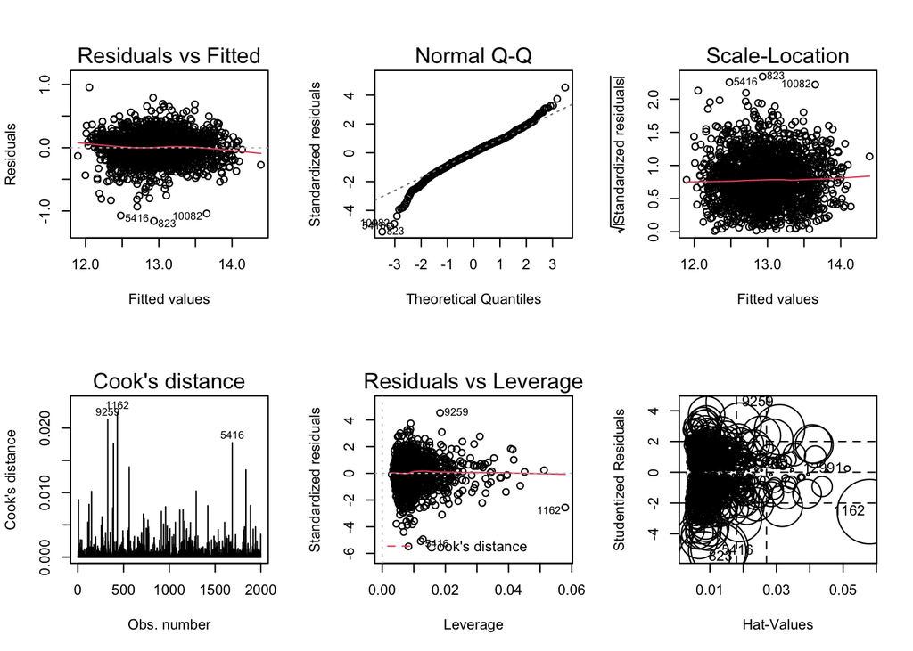

```
## 异常值/强影响点检验
##        rstudent unadjusted p-value Bonferroni p
## 823   -5.516625         3.9089e-08   7.8178e-05
## 5416  -5.113692         3.4637e-07   6.9274e-04
## 10082 -4.956551         7.7857e-07   1.5571e-03
## 9259   4.556883         5.5083e-06   1.1017e-02
## 8641  -4.416299         1.0582e-05   2.1164e-02
##
## 异方差检验
## Non-constant Variance Score Test
## Variance formula: ~ fitted.values
## Chisquare = 2.627396, Df = 1, p = 0.10503
##
##  studentized Breusch-Pagan test
##
## data:  fit
## BP = 90.894, df = 17, p-value = 4.197e-12
##
##
##  Goldfeld-Quandt test
##
## data:  fit
## GQ = 0.8967, df1 = 982, df2 = 982, p-value = 0.9561
## alternative hypothesis: variance increases from segment 1 to 2
##
##
## 共线性检验
##                            GVIF Df GVIF^(1/(2*Df))
## 居住面积               1.946968  1        1.395338
## 楼层数                 1.794051  1        1.339422
## 视野                   1.157882  1        1.076049
## 成色                   1.300457  1        1.140376
## 建筑设计水平           2.543039  1        1.594691
## 建筑年份               8.032101  1        2.834096
## 经度                   3.302800  1        1.817361
## 每间卧室平均浴室数     1.416977  1        1.190368
## 距最近优质啤酒厂的距离 6.296110  1        2.509205
## 距医院的交通距离       3.401476  1        1.844309
## 销售年份               2.855405  1        1.689794
## 销售季度               2.904712  3        1.194494
## 是否位于西雅图         3.418192  1        1.848835
## 最近一次翻新距今年份   8.014117  1        2.830922
## 是否邻近海岸           1.136968  1        1.066287
##
## 自相关检验
##  lag Autocorrelation D-W Statistic p-value
##    1      0.03806679      1.923556    0.08
##  Alternative hypothesis: rho != 0
```

联系异常值/强影响点检验、残差与真实值关系图（Residuals vs Fitted）以及COOK距离图，删去点823、5416、10082和9259对应数据。

共线性检验中，所有变量的VIF值均小于10，相对较高的是建筑年份（8.032101）和最近一次翻新距今年份的VIF值（8.014117），其原因可能在于两者都是时间变量，存在一定相关性。这里删去翻新距今年份的自变量。

对于自相关检验，自相关系数近似为0，DW统计量也趋近于2，故近似认为不存在自相关。

## 模型三：诊断、处理后重新回归

```
##
## Call:
## lm(formula = log(销售价格) ~ 居住面积 + 楼层数 + 视野 +
##     成色 + 建筑设计水平 + 建筑年份 + 经度 + 每间卧室平均浴室数 +
##     距最近优质啤酒厂的距离 + 距医院的交通距离 +
##     销售年份 + 销售季度 + 是否位于西雅图 + 是否邻近海岸,
##     data = data2)
##
## Residuals:
##      Min       1Q   Median       3Q      Max
## -1.10145 -0.12236  0.00539  0.12651  1.00344
##
## Coefficients:
##                          Estimate Std. Error t value Pr(>|t|)
## (Intercept)             8.268e+01  7.912e+00  10.450  < 2e-16 ***
## 居住面积                2.430e-04  8.809e-06  27.590  < 2e-16 ***
## 楼层数                  3.088e-02  1.056e-02   2.923  0.00350 **
## 视野                    5.385e-02  8.131e-03   6.623 4.53e-11 ***
## 成色                    5.128e-02  7.450e-03   6.883 7.82e-12 ***
## 建筑设计水平            1.451e-01  7.471e-03  19.424  < 2e-16 ***
## 建筑年份               -1.991e-03  2.323e-04  -8.573  < 2e-16 ***
## 经度                    5.483e-01  6.442e-02   8.511  < 2e-16 ***
## 每间卧室平均浴室数     -3.093e-02  7.797e-03  -3.967 7.53e-05 ***
## 距最近优质啤酒厂的距离 -2.406e-02  1.567e-03 -15.349  < 2e-16 ***
## 距医院的交通距离       -9.281e-01  5.585e-02 -16.617  < 2e-16 ***
## 销售年份2015            7.170e-02  1.605e-02   4.467 8.37e-06 ***
## 销售季度Q2              4.694e-02  1.596e-02   2.941  0.00331 **
## 销售季度Q3              4.891e-02  2.110e-02   2.318  0.02056 *
## 销售季度Q4              3.858e-02  2.133e-02   1.808  0.07069 .
## 是否位于西雅图是       -1.044e-01  1.669e-02  -6.258 4.75e-10 ***
## 是否邻近海岸是          9.338e-02  1.868e-02   4.999 6.28e-07 ***
## ---
## Signif. codes:  0 '***' 0.001 '**' 0.01 '*' 0.05 '.' 0.1 ' ' 1
##
## Residual standard error: 0.2007 on 1983 degrees of freedom
## Multiple R-squared:  0.8086, Adjusted R-squared:  0.807
## F-statistic: 523.4 on 16 and 1983 DF,  p-value: < 2.2e-16
```

```
## Start:  AIC=-6407.07
## log(销售价格) ~ 居住面积 + 楼层数 + 视野 + 成色 +
##     建筑设计水平 + 建筑年份 + 经度 + 每间卧室平均浴室数 +
##     距最近优质啤酒厂的距离 + 距医院的交通距离 +
##     销售年份 + 销售季度 + 是否位于西雅图 + 是否邻近海岸
##
##                          Df Sum of Sq     RSS     AIC
## <none>                                 79.868 -6407.1
## - 销售季度                3    0.3766  80.244 -6403.7
## - 楼层数                  1    0.3442  80.212 -6400.5
## - 每间卧室平均浴室数      1    0.6339  80.501 -6393.3
## - 销售年份                1    0.8037  80.671 -6389.0
## - 是否邻近海岸            1    1.0064  80.874 -6384.0
## - 是否位于西雅图          1    1.5775  81.445 -6369.9
## - 视野                    1    1.7665  81.634 -6365.3
## - 成色                    1    1.9083  81.776 -6361.8
## - 经度                    1    2.9177  82.785 -6337.3
## - 建筑年份                1    2.9603  82.828 -6336.3
## - 距最近优质啤酒厂的距离  1    9.4883  89.356 -6184.6
## - 距医院的交通距离        1   11.1215  90.989 -6148.3
## - 建筑设计水平            1   15.1966  95.064 -6060.7
## - 居住面积                1   30.6575 110.525 -5759.3
```

```
##
## Call:
## lm(formula = log(销售价格) ~ 居住面积 + 楼层数 + 视野 +
##     成色 + 建筑设计水平 + 建筑年份 + 经度 + 每间卧室平均浴室数 +
##     距最近优质啤酒厂的距离 + 距医院的交通距离 +
##     销售年份 + 销售季度 + 是否位于西雅图 + 是否邻近海岸,
##     data = data2)
##
## Residuals:
##      Min       1Q   Median       3Q      Max
## -1.10145 -0.12236  0.00539  0.12651  1.00344
##
## Coefficients:
##                          Estimate Std. Error t value Pr(>|t|)
## (Intercept)             8.268e+01  7.912e+00  10.450  < 2e-16 ***
## 居住面积                2.430e-04  8.809e-06  27.590  < 2e-16 ***
## 楼层数                  3.088e-02  1.056e-02   2.923  0.00350 **
## 视野                    5.385e-02  8.131e-03   6.623 4.53e-11 ***
## 成色                    5.128e-02  7.450e-03   6.883 7.82e-12 ***
## 建筑设计水平            1.451e-01  7.471e-03  19.424  < 2e-16 ***
## 建筑年份               -1.991e-03  2.323e-04  -8.573  < 2e-16 ***
## 经度                    5.483e-01  6.442e-02   8.511  < 2e-16 ***
## 每间卧室平均浴室数     -3.093e-02  7.797e-03  -3.967 7.53e-05 ***
## 距最近优质啤酒厂的距离 -2.406e-02  1.567e-03 -15.349  < 2e-16 ***
## 距医院的交通距离       -9.281e-01  5.585e-02 -16.617  < 2e-16 ***
## 销售年份2015            7.170e-02  1.605e-02   4.467 8.37e-06 ***
## 销售季度Q2              4.694e-02  1.596e-02   2.941  0.00331 **
## 销售季度Q3              4.891e-02  2.110e-02   2.318  0.02056 *
## 销售季度Q4              3.858e-02  2.133e-02   1.808  0.07069 .
## 是否位于西雅图是       -1.044e-01  1.669e-02  -6.258 4.75e-10 ***
## 是否邻近海岸是          9.338e-02  1.868e-02   4.999 6.28e-07 ***
## ---
## Signif. codes:  0 '***' 0.001 '**' 0.01 '*' 0.05 '.' 0.1 ' ' 1
##
## Residual standard error: 0.2007 on 1983 degrees of freedom
## Multiple R-squared:  0.8086, Adjusted R-squared:  0.807
## F-statistic: 523.4 on 16 and 1983 DF,  p-value: < 2.2e-16
```

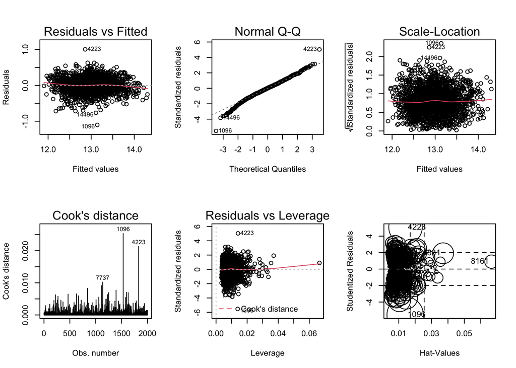

```
## 异常值/强影响点检验
##       rstudent unadjusted p-value Bonferroni p
## 1096 -5.568612         2.9175e-08   5.8351e-05
## 4223  5.066876         4.4194e-07   8.8387e-04
##
## 异方差检验
## Non-constant Variance Score Test
## Variance formula: ~ fitted.values
## Chisquare = 2.326226, Df = 1, p = 0.12721
##
##  studentized Breusch-Pagan test
##
## data:  fit
## BP = 75.398, df = 16, p-value = 1.111e-09
##
##
##  Goldfeld-Quandt test
##
## data:  fit
## GQ = 1.1567, df1 = 983, df2 = 983, p-value = 0.01129
## alternative hypothesis: variance increases from segment 1 to 2
##
##
## 共线性检验
##                            GVIF Df GVIF^(1/(2*Df))
## 居住面积               2.005895  1        1.416296
## 楼层数                 1.711560  1        1.308266
## 视野                   1.168376  1        1.080914
## 成色                   1.206981  1        1.098627
## 建筑设计水平           2.602372  1        1.613187
## 建筑年份               2.718968  1        1.648929
## 经度                   3.390552  1        1.841345
## 每间卧室平均浴室数     1.379702  1        1.174607
## 距最近优质啤酒厂的距离 6.309886  1        2.511949
## 距医院的交通距离       3.473585  1        1.863756
## 销售年份               2.799681  1        1.673225
## 销售季度               2.821628  3        1.188730
## 是否位于西雅图         3.454917  1        1.858741
## 是否邻近海岸           1.135576  1        1.065634
##
## 自相关检验
##  lag Autocorrelation D-W Statistic p-value
##    1      0.01926643      1.959532    0.34
##  Alternative hypothesis: rho != 0
```

R^2也有较为明显的提升。（从0.7848到0.8071）

## 平方项设计

通过观察各项变量与因变量之间的散点图/箱线图，观察有没有先高后低/先低后高的情况，据此设计了两个平方项。

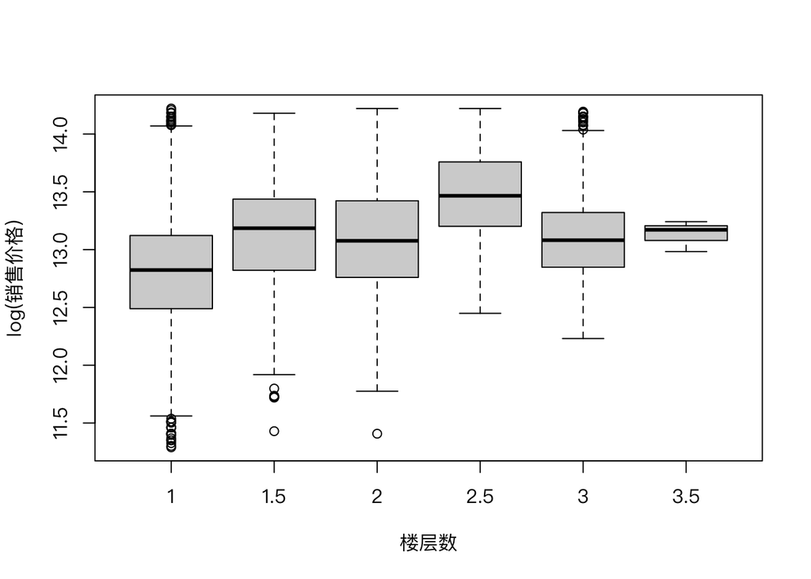

#### (纬度-47.65)^2

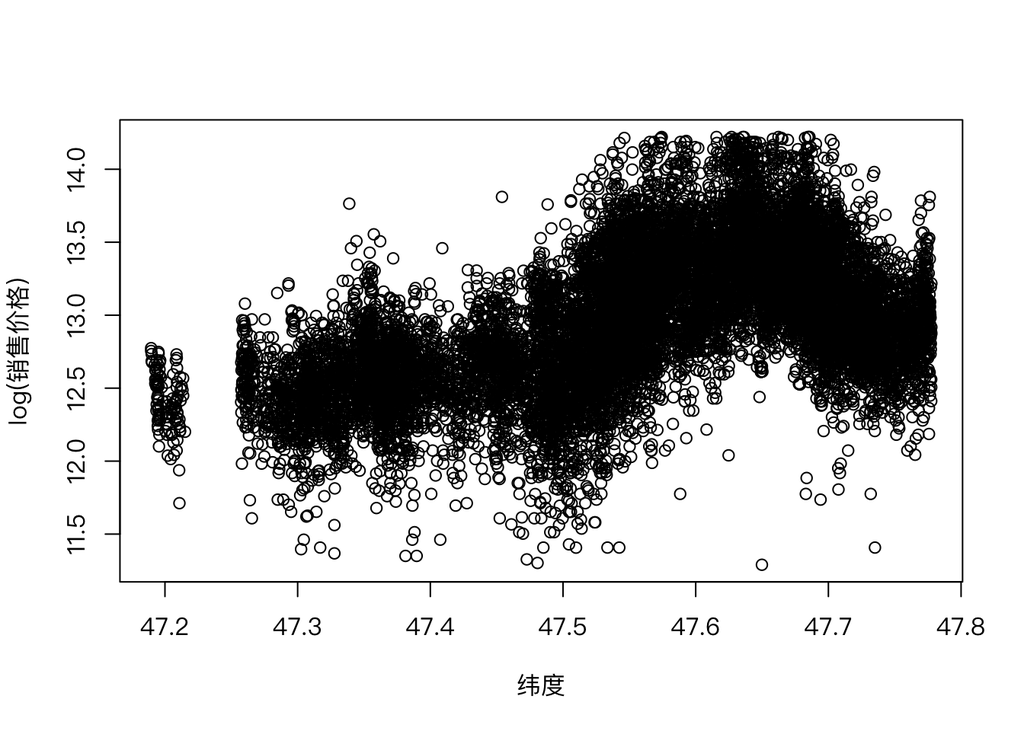

## 模型四：尝试加入平方项

自变量选择、回归诊断等步骤同上，此处省略，直接展示最终模型的结果。

```
##
## Call:
## lm(formula = log(销售价格) ~ 居住面积 + 土地面积 +
##     I((楼层数 - 2.5)^2) + 视野 + 成色 + 建筑设计水平 +
##     建筑年份 + I((纬度 - 47.65)^2) + 经度 + 每间卧室平均浴室数 +
##     有无地下室 + 距最近优质啤酒厂的距离 + 距医院的交通距离 +
##     销售年份 + 销售季度 + 是否位于西雅图 + 是否邻近海岸,
##     data = data3)
##
## Residuals:
##      Min       1Q   Median       3Q      Max
## -1.19484 -0.12283  0.00527  0.13164  0.98375
##
## Coefficients:
##                          Estimate Std. Error t value Pr(>|t|)
## (Intercept)             7.720e+01  1.299e+01   5.945 3.27e-09 ***
## 居住面积                2.494e-04  1.084e-05  23.009  < 2e-16 ***
## 土地面积                3.634e-07  2.830e-06   0.128 0.897830
## I((楼层数 - 2.5)^2)    -1.912e-02  7.709e-03  -2.481 0.013196 *
## 视野                    5.687e-02  8.525e-03   6.671 3.29e-11 ***
## 成色                    4.637e-02  7.974e-03   5.815 7.04e-09 ***
## 建筑设计水平            1.400e-01  7.691e-03  18.202  < 2e-16 ***
## 建筑年份               -1.908e-03  2.349e-04  -8.125 7.76e-16 ***
## I((纬度 - 47.65)^2)    -1.453e-01  3.806e-01  -0.382 0.702575
## 经度                    5.041e-01  1.065e-01   4.736 2.34e-06 ***
## 每间卧室平均浴室数     -1.809e-02  8.230e-03  -2.199 0.028028 *
## 有无地下室有            2.410e-03  1.203e-02   0.200 0.841263
## 距最近优质啤酒厂的距离 -2.145e-02  3.272e-03  -6.555 7.08e-11 ***
## 距医院的交通距离       -9.787e-01  5.818e-02 -16.820  < 2e-16 ***
## 销售年份2015            6.572e-02  1.691e-02   3.887 0.000105 ***
## 销售季度Q2              4.159e-02  1.702e-02   2.443 0.014652 *
## 销售季度Q3              4.504e-02  2.200e-02   2.047 0.040790 *
## 销售季度Q4              1.746e-02  2.231e-02   0.782 0.434019
## 是否位于西雅图是       -7.636e-02  1.757e-02  -4.346 1.46e-05 ***
## 是否邻近海岸是          1.083e-01  2.046e-02   5.294 1.33e-07 ***
## ---
## Signif. codes:  0 '***' 0.001 '**' 0.01 '*' 0.05 '.' 0.1 ' ' 1
##
## Residual standard error: 0.2083 on 1980 degrees of freedom
## Multiple R-squared:  0.7949, Adjusted R-squared:  0.7929
## F-statistic: 403.9 on 19 and 1980 DF,  p-value: < 2.2e-16
```

```
## Start:  AIC=-6255.37
## log(销售价格) ~ 居住面积 + 土地面积 + I((楼层数 -
##     2.5)^2) + 视野 + 成色 + 建筑设计水平 + 建筑年份 +
##     I((纬度 - 47.65)^2) + 经度 + 每间卧室平均浴室数 +
##     有无地下室 + 距最近优质啤酒厂的距离 + 距医院的交通距离 +
##     销售年份 + 销售季度 + 是否位于西雅图 + 是否邻近海岸
##
##                          Df Sum of Sq     RSS     AIC
## - 土地面积                1    0.0007  85.904 -6257.4
## - 有无地下室              1    0.0017  85.905 -6257.3
## - I((纬度 - 47.65)^2)     1    0.0063  85.909 -6257.2
## <none>                                 85.903 -6255.4
## - 每间卧室平均浴室数      1    0.2097  86.112 -6252.5
## - I((楼层数 - 2.5)^2)     1    0.2670  86.170 -6251.2
## - 销售季度                3    0.4675  86.370 -6250.5
## - 销售年份                1    0.6556  86.558 -6242.2
## - 是否位于西雅图          1    0.8194  86.722 -6238.4
## - 经度                    1    0.9730  86.876 -6234.8
## - 是否邻近海岸            1    1.2157  87.118 -6229.3
## - 成色                    1    1.4672  87.370 -6223.5
## - 距最近优质啤酒厂的距离  1    1.8641  87.767 -6214.4
## - 视野                    1    1.9308  87.834 -6212.9
## - 建筑年份                1    2.8644  88.767 -6191.8
## - 距医院的交通距离        1   12.2740  98.177 -5990.3
## - 建筑设计水平            1   14.3733 100.276 -5948.0
## - 居住面积                1   22.9691 108.872 -5783.5
##
## Step:  AIC=-6257.36
## log(销售价格) ~ 居住面积 + I((楼层数 - 2.5)^2) + 视野 +
##     成色 + 建筑设计水平 + 建筑年份 + I((纬度 -
##     47.65)^2) + 经度 + 每间卧室平均浴室数 + 有无地下室 +
##     距最近优质啤酒厂的距离 + 距医院的交通距离 +
##     销售年份 + 销售季度 + 是否位于西雅图 + 是否邻近海岸
##
##                          Df Sum of Sq     RSS     AIC
## - 有无地下室              1    0.0014  85.905 -6259.3
## - I((纬度 - 47.65)^2)     1    0.0072  85.911 -6259.2
## <none>                                 85.904 -6257.4
## - 每间卧室平均浴室数      1    0.2101  86.114 -6254.5
## - 销售季度                3    0.4678  86.371 -6252.5
```

[output cut: 45 more lines]

```
## <none>                                 85.912 -6261.2
## - 每间卧室平均浴室数      1     0.218  86.130 -6258.1
## - 销售季度                3     0.467  86.379 -6256.3
## - I((楼层数 - 2.5)^2)     1     0.361  86.273 -6254.8
## - 销售年份                1     0.654  86.566 -6248.0
## - 是否位于西雅图          1     0.863  86.775 -6243.2
## - 是否邻近海岸            1     1.213  87.125 -6235.1
## - 成色                    1     1.466  87.377 -6229.3
## - 视野                    1     1.945  87.857 -6218.4
## - 经度                    1     2.808  88.720 -6198.8
## - 建筑年份                1     2.989  88.901 -6194.8
## - 距最近优质啤酒厂的距离  1     8.367  94.279 -6077.3
## - 距医院的交通距离        1    12.417  98.329 -5993.2
## - 建筑设计水平            1    14.495 100.407 -5951.3
## - 居住面积                1    32.349 118.261 -5624.0
```

```
##
## Call:
## lm(formula = log(销售价格) ~ 居住面积 + I((楼层数 -
##     2.5)^2) + 视野 + 成色 + 建筑设计水平 + 建筑年份 +
##     经度 + 每间卧室平均浴室数 + 距最近优质啤酒厂的距离 +
##     距医院的交通距离 + 销售年份 + 销售季度 +
##     是否位于西雅图 + 是否邻近海岸, data = data3)
##
## Residuals:
##      Min       1Q   Median       3Q      Max
## -1.19424 -0.12272  0.00483  0.13170  0.98241
##
## Coefficients:
##                          Estimate Std. Error t value Pr(>|t|)
## (Intercept)             8.083e+01  8.146e+00   9.923  < 2e-16 ***
## 居住面积                2.510e-04  9.184e-06  27.325  < 2e-16 ***
## I((楼层数 - 2.5)^2)    -1.779e-02  6.158e-03  -2.889 0.003913 **
## 视野                    5.702e-02  8.510e-03   6.700 2.71e-11 ***
## 成色                    4.621e-02  7.944e-03   5.817 6.99e-09 ***
## 建筑设计水平            1.398e-01  7.642e-03  18.292  < 2e-16 ***
## 建筑年份               -1.898e-03  2.285e-04  -8.306  < 2e-16 ***
## 经度                    5.340e-01  6.632e-02   8.051 1.40e-15 ***
## 每间卧室平均浴室数     -1.807e-02  8.049e-03  -2.244 0.024911 *
## 距最近优质啤酒厂的距离 -2.251e-02  1.620e-03 -13.897  < 2e-16 ***
## 距医院的交通距离       -9.757e-01  5.763e-02 -16.929  < 2e-16 ***
## 销售年份2015            6.562e-02  1.689e-02   3.885 0.000106 ***
## 销售季度Q2              4.167e-02  1.701e-02   2.450 0.014354 *
## 销售季度Q3              4.506e-02  2.198e-02   2.050 0.040486 *
## 销售季度Q4              1.761e-02  2.229e-02   0.790 0.429492
## 是否位于西雅图是       -7.621e-02  1.708e-02  -4.463 8.54e-06 ***
## 是否邻近海岸是          1.080e-01  2.041e-02   5.292 1.35e-07 ***
## ---
## Signif. codes:  0 '***' 0.001 '**' 0.01 '*' 0.05 '.' 0.1 ' ' 1
##
## Residual standard error: 0.2081 on 1983 degrees of freedom
## Multiple R-squared:  0.7949, Adjusted R-squared:  0.7932
## F-statistic: 480.3 on 16 and 1983 DF,  p-value: < 2.2e-16
```

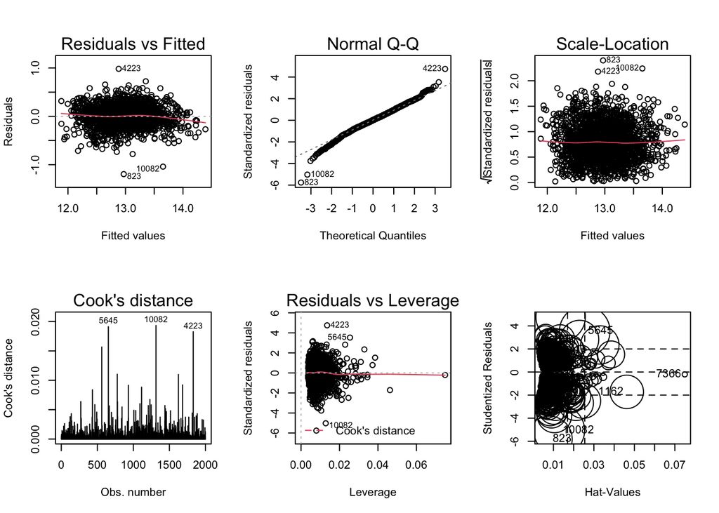

```
## 异常值/强影响点检验
##        rstudent unadjusted p-value Bonferroni p
## 823   -5.807884         7.3524e-09   1.4705e-05
## 10082 -5.057808         4.6319e-07   9.2638e-04
## 4223   4.778287         1.8978e-06   3.7956e-03
##
## 异方差检验
## Non-constant Variance Score Test
## Variance formula: ~ fitted.values
## Chisquare = 1.772378, Df = 1, p = 0.18309
##
##  studentized Breusch-Pagan test
##
## data:  fit
## BP = 80.822, df = 16, p-value = 1.183e-10
##
##
##  Goldfeld-Quandt test
##
## data:  fit
## GQ = 1.1302, df1 = 983, df2 = 983, p-value = 0.02759
## alternative hypothesis: variance increases from segment 1 to 2
##
##
## 共线性检验
##                            GVIF Df GVIF^(1/(2*Df))
## 居住面积               2.027796  1        1.424007
## I((楼层数 - 2.5)^2)    1.579702  1        1.256862
## 视野                   1.174780  1        1.083873
## 成色                   1.239884  1        1.113501
## 建筑设计水平           2.540557  1        1.593912
## 建筑年份               2.500009  1        1.581142
## 经度                   3.532003  1        1.879362
## 每间卧室平均浴室数     1.397895  1        1.182326
## 距最近优质啤酒厂的距离 6.343846  1        2.518699
## 距医院的交通距离       3.352407  1        1.830958
## 销售年份               2.834497  1        1.683597
## 销售季度               2.861169  3        1.191491
## 是否位于西雅图         3.362283  1        1.833653
## 是否邻近海岸           1.126327  1        1.061286
##
## 自相关检验
##  lag Autocorrelation D-W Statistic p-value
##    1     -0.01788778      2.034987   0.434
##  Alternative hypothesis: rho != 0
```

# 模型解释

### 对房价无明显影响的变量

在逐步回归中被去掉，或未被去掉但在最终模型中不显著的变量，被视作对房价无明显影响。